# Single-cell visualizations

Jaclyn Taroni

2025

In this notebook, we will create visualizations for individual cell subgroup predictions in the 10X ([Riemondy, et al.](https://doi.org/10.1093/neuonc/noab135)) and Smart-seq2 data ([Hovestadt, et al.](https://www.nature.com/articles/s41586-019-1434-6)).

For the Smart-seq2 dataset, we will not use any filtering to remove cells with too few classifier-relevant genes observed, as we did not see that improve “accuracy” in `analyze_prop_observed_single_cells.Rmd`.

For the 10X dataset, we will filter out cells that have less than 10% of informative genes observed. The 10X dataset additionally has metadata available from UCSC Cell Browser that includes cell type labels and QC measures.

## Setup

```r
set.seed(2025)
```

### Libraries

```r
library(ggplot2)
library(ggridges)
library(patchwork)
```

### Source

We only need the color schemes.

```r
source(here::here("utils", "color_schemes.R"))
```

### Directories

```r
# Set up directories
tenx_data_dir <- here::here("data",
                            "GSE155446")
sc_results_dir <- here::here("results",
                             "single_cells_filtered")
plots_data_dir <- here::here("plots", "data")
plots_dir <- here::here("plots")
```

### Input files

```r
# 10X metadata from UCSC Cell Browser
tenx_metadata_file <- here::here(tenx_data_dir,
                                 "meta.tsv")

# Table with UMAP coords, cluster ID, etc.
umap_cluster_file <- here::here(plots_data_dir,
                                "single_cell_umap_coord_cluster.tsv")

# We don't want to do any filtering for the Smart-seq2 dataset
no_filter_rf_results_file <- here::here(sc_results_dir,
                                        "rf_0.00.tsv")
no_filter_ktsp_results_file <- here::here(sc_results_dir,
                                          "ktsp_0.00_gene.tsv")

# 0.1, gene-based filtering for the 10X dataset
tenperc_rf_results_file <- here::here(sc_results_dir,
                                      "rf_0.10.tsv")
tenperc_ktsp_results_file <- here::here(sc_results_dir,
                                        "ktsp_0.10_gene.tsv")

# Put all together for convenience
results_files <- c(no_filter_ktsp_results_file,
                   no_filter_rf_results_file,
                   tenperc_ktsp_results_file,
                   tenperc_rf_results_file)
```

### Output files

#### Data

```r
tenx_results_file <- here::here(plots_data_dir,
                                "10x_single_cell_test_predictions.tsv")
smartseq_results_file <- here::here(plots_data_dir,
                                    "smartseq_single_cell_test_predictions.tsv")
malignant_qc_stats_file <- here::here(plots_data_dir,
                                      "10x_malignant_cell_quality_stats.tsv")
```

#### Plots

```r
stacked_barplot_file <- here::here(plots_dir,
                                   "10x_cell_type_subgroup_stacked_bar.pdf")
ridgeplot_file <- here::here(plots_dir,
                             "10x_malignant_cell_quality_ridge.pdf")
umap_plots_file <- here::here(plots_dir,
                              "single_cell_UMAPs_G3_G4_samples.pdf")
```

## Read in and wrangle data

Read in all of the individual cell prediction files that we’re going to use for plotting.

```r
# Create a data frame with all the results
results_df <- results_files |>
  purrr::map(readr::read_tsv,
             progress = FALSE,
             show_col_types = FALSE) |>
  # Set names based on file names
  purrr::set_names(stringr::str_remove(basename(results_files), "\\.tsv")) |>
  # Bind data frames together
  dplyr::bind_rows(.id = "run") |>
  # Use the file name to pull out the parameters that were used to generate the
  # results into columns
  dplyr::mutate(
    prop_observed = as.numeric(stringr::word(run, 2, sep = "_")),
    filtering_type = stringr::word(run, 3, sep = "_")
  ) |>
  # Drop identifier derived from file names
  dplyr::select(-run)
```

Read in file that contains the UMAP coordinates and cluster labels for all individual cells in both datasets.

```r
umap_cluster_df <- readr::read_tsv(umap_cluster_file,
                                   show_col_types = FALSE) |>
  # Concatenate sample identifier and barcode for 10x data, which allows for
  # joining with the metadata from UCSC Cell Browser
  dplyr::mutate(cell_id = dplyr::case_when(
    !is.na(barcode) ~ stringr::str_c(sample_accession, barcode, sep = "_"),
    TRUE ~ NA
  )) |>
  dplyr::select(-barcode)
```

### Smart-seq2 dataset

For the Smart-seq2 dataset, we observed no benefit to employing a more aggressive filtering strategy, so we will move forward with results that have filtering > 0 in place.

```r
# Use filter > 0 strategy for Smart-seq2 dataset
smartseq_results_df <- results_df |>
  dplyr::filter(study == "GSE119926",
                prop_observed == 0,
                model_type == "RF (w)" |
                  # This filtering_type is just to avoid duplicates -- the
                  # results between strategies with no filtering should be the
                  # same
                  model_type == "kTSP (unw)" & filtering_type == "gene")
```

Add the UMAP coordinates and cluster labels to the Smart-seq2 results

```r
smartseq_results_df <- smartseq_results_df |>
  dplyr::left_join(umap_cluster_df, by = c("sample_accession", "cell_index")) |>
  # The cell_id column is all NA for this dataset because there are no barcodes
  # so we can drop it
  dplyr::select(-cell_id)
```

Write to file.

```r
readr::write_tsv(smartseq_results_df, file = smartseq_results_file)
```

### 10X dataset

For the 10X dataset, using a gene-based filtering strategy where at least 10% of the genes in rules was observed resulted in a small benefit, particularly for the kTSP model.

```r
# For the 10x dataset, use 0.1 proportion observed using the gene-based strategy
tenx_results_df <- results_df |>
  dplyr::filter(study == "GSE155446",
                prop_observed == 0.1,
                model_type == "RF (w)" |
                  model_type == "kTSP (unw)" & filtering_type == "gene")

# Remove larger, unfiltered data frame
rm(results_df)
```

Combine the predicted results, cell type labels obtained from UCSC Cell Browser, UMAP coordinates, and cluster labels for the 10X dataset.

```r
# Read in metadata from UCSC Cell Browser
tenx_meta_df <- readr::read_tsv(tenx_metadata_file,
                                show_col_types = FALSE)

# Join the cell type labels from UCSC Cell Browser with the UMAP coordinates
# and cluster labels
tenx_meta_df <- tenx_meta_df |>
  # We want the cell type labels and QC information from UCSC Cell Browser only
  dplyr::select(Cell,
                cell_type,
                genes_per_cell = `genes per cell`,
                umis_per_cell = `UMIs per cell`,
                percent_mito = `percent of UMIs as mitochondria`) |>
  # Keep only the 10X data for this particular data frame and drop the samples
  # that we removed due to label ambiguity -- hence the inner join
  dplyr::inner_join(umap_cluster_df, by = c("Cell" = "cell_id")) |>
  # Drop the cell identifier now that joining is complete
  dplyr::select(-Cell)

# Add this metadata to the results data frame
tenx_results_df <- tenx_results_df |>
  dplyr::left_join(tenx_meta_df,
                   by = c("sample_accession", "cell_index"))

# Remove table of just metadata
rm(tenx_meta_df)
```

Write the 10x data for plotting to file.

```r
readr::write_tsv(tenx_results_df, file = tenx_results_file)
```

## 10X Cell Type exploration

We are interested in what subgroup different cell types get labeled as using the different pair-based classifiers. We only have cell type labels for the 10X dataset.

### Stacked barplot

We’ll make a stacked bar plot to examine the relationship between cell type label and predicted subgroup label.

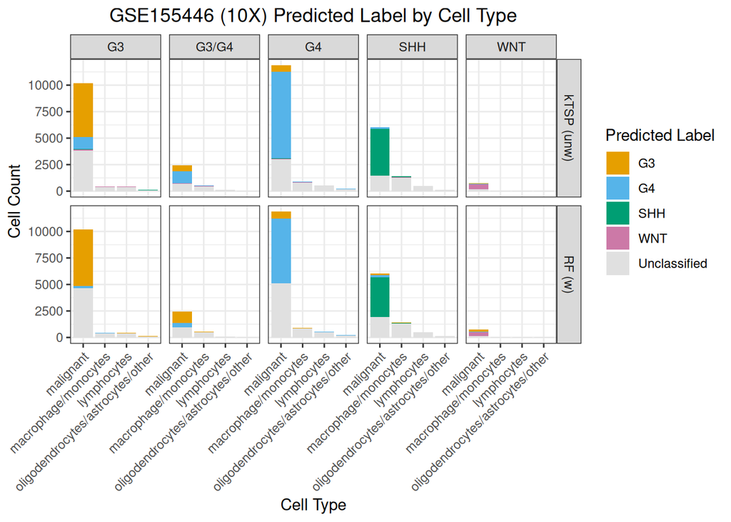

```r
stacked_barplot <- tenx_results_df |>
  # Clean up the cell type labels just for display
  dplyr::mutate(cell_type = stringr::str_replace_all(cell_type, "_", "/")) |>
  # Make sure the predicted labels are ordered the same as the color palette
  # and order the cell types a particular way
  dplyr::mutate(predicted_labels = factor(predicted_labels,
                                          levels = names(subgroup_colors)),
                cell_type = factor(cell_type,
                                   levels = c(
                                     "malignant",
                                     "macrophage/monocytes",
                                     "lymphocytes",
                                     "oligodendrocytes/astrocytes/other"
                                   ))) |>
  ggplot(
    aes(
      x = cell_type,
      fill = predicted_labels
    )
  ) +
  geom_bar() +
  facet_grid(col = vars(subgroup),
             row = vars(model_type)) +
  theme_bw() +
  scale_fill_manual(values = subgroup_colors) +
  labs(x = "Cell Type",
       y = "Cell Count",
       fill = "Predicted Label",
       title = "GSE155446 (10X) Predicted Label by Cell Type") +
  theme(axis.text.x = element_text(angle = 45, hjust = 1),
        plot.title = element_text(hjust = 0.5))

stacked_barplot
```

It looks like non-malignant cells tend to be unclassified (i.e., because not enough relevant genes are observed).

Let’s save the plot to file.

```r
ggsave(plot = stacked_barplot,
       file = stacked_barplot_file,
       width = 7,
       height = 5,
       unit = "in")
```

### Quality of malignant cells by predicted subgroup label

Is there a difference in quality between malignant cells that are predicted to have different subgroup labels (including unclassified)?

Create a long data frame that holds the QC metrics from UCSC Cell Browser.

```r
malignant_cell_qc_df <- tenx_results_df |>
  # Only the malignant cells
  dplyr::filter(cell_type == "malignant") |>
  # Only retain the columns we need for plotting
  dplyr::select(sample_accession,
                cell_index,
                predicted_labels,
                model_type,
                genes_per_cell,
                umis_per_cell,
                percent_mito) |>
  # Long form so we can facet by the different QC measures
  tidyr::pivot_longer(cols = c(genes_per_cell, percent_mito, umis_per_cell),
                      names_to = "measure") |>
  # Order the predicted labels in the same order of the palette for display
  dplyr::mutate(predicted_labels = factor(predicted_labels,
                                          levels = names(subgroup_colors))) |>
  # Clean up the measure names for display
  dplyr::mutate(measure = dplyr::case_when(
    measure == "genes_per_cell" ~ "Genes Per Cell",
    measure == "umis_per_cell" ~ "UMIs Per Cell",
    measure == "percent_mito" ~ "% Mitochondrial"
  ))
```

Make a ridge plot looking at the distribution of these measures, where density for each predicted subgroup is plotted separately, and rows are model type, columns are individual QC measures

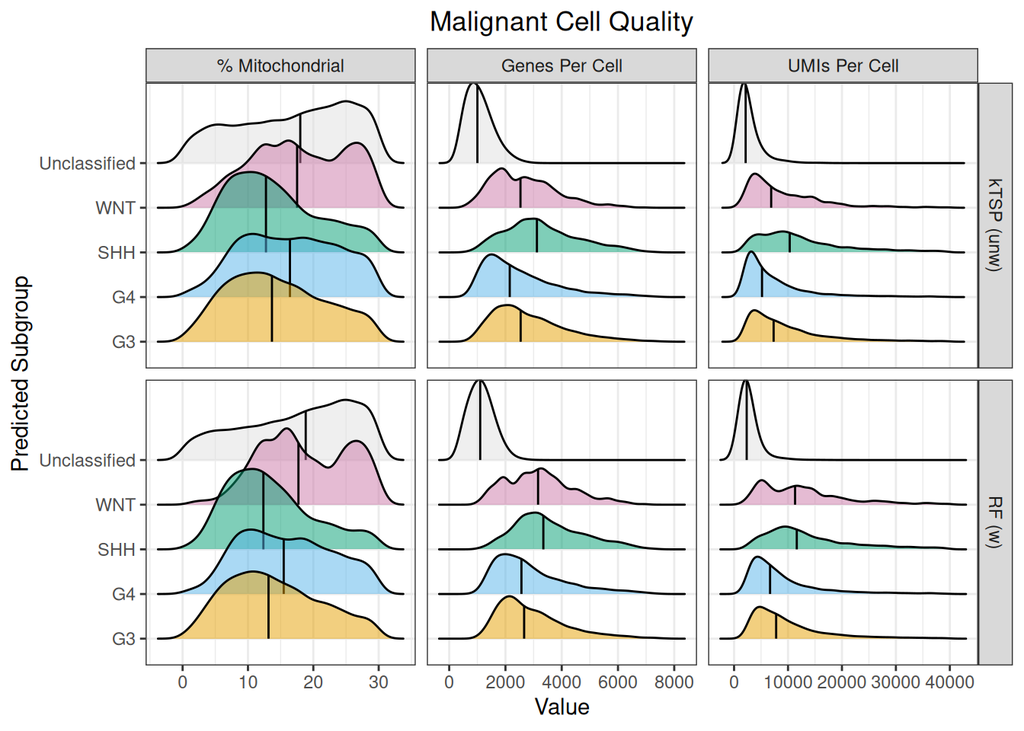

```r
malignant_ridge_plot <- malignant_cell_qc_df |>
  ggplot(
    aes(
      x = value,
      y = predicted_labels,
      fill = predicted_labels
    )
  ) +
  geom_density_ridges(alpha = 0.5,
                      quantile_lines = TRUE,
                      quantile_fun = median) +
  theme_bw() +
  facet_grid(rows = vars(model_type),
             cols = vars(measure),
             scales = "free_x") +
  scale_fill_manual(values = subgroup_colors) +
  labs(x = "Value",
       y = "Predicted Subgroup",
       title = "Malignant Cell Quality") +
  theme(legend.position = "none",
        plot.title = element_text(hjust = 0.5))

malignant_ridge_plot
```

It looks like malignant cells that are unclassified (i.e., because too few relevant genes are observed) tend to have fewer genes per cell and perhaps higher mitochondrial content.

Taken together, this suggests that the pair-based classifiers – and kTSP in particular – do well at classification for cancerous cells of sufficient quality.

```r
ggsave(file = ridgeplot_file,
       plot = malignant_ridge_plot,
       width = 7,
       height = 5,
       units = "in")
```

#### Stats

Are the differences in quality between classified and unclassified malignant cells statistically significant?

```r
# Add a new column tracking whether or not something is classified to use for
# statistical test
malignant_cell_qc_df <- malignant_cell_qc_df |>
  dplyr::mutate(classification = dplyr::if_else(
    predicted_labels == "Unclassified", "Unclassified", "Classified")
  )

# Test for differences for each model type-measure pair
stats_df <- malignant_cell_qc_df |>
  dplyr::group_by(model_type, measure) |>
  rstatix::wilcox_test(value ~ classification,
                       p.adjust.method = "bonferroni")

# Add effect size information
effect_size_df <- malignant_cell_qc_df |>
  dplyr::group_by(model_type, measure) |>
  rstatix::wilcox_effsize(value ~ classification)
stats_df <- stats_df |>
  dplyr::inner_join(effect_size_df)
stats_df
```

| model_type | measure | .y. | group1 | group2 | n1 | n2 | statistic | p | effsize | magnitude |
| --- | --- | --- | --- | --- | --- | --- | --- | --- | --- | --- |
| RF (w) | % Mitochondrial | value | Classified | Unclassified | 18457 | 12788 | 92459546 | 4.51e-233 | 0.18441187 | small |
| RF (w) | Genes Per Cell | value | Classified | Unclassified | 18457 | 12788 | 227436313 | 0.00e+00 | 0.78963603 | large |
| RF (w) | UMIs Per Cell | value | Classified | Unclassified | 18457 | 12788 | 220127026 | 0.00e+00 | 0.73688918 | large |
| kTSP (unw) | % Mitochondrial | value | Classified | Unclassified | 22136 | 9109 | 89597880 | 4.35e-54 | 0.08760556 | small |
| kTSP (unw) | Genes Per Cell | value | Classified | Unclassified | 22136 | 9109 | 184532840 | 0.00e+00 | 0.65360980 | large |
| kTSP (unw) | UMIs Per Cell | value | Classified | Unclassified | 22136 | 9109 | 175581916 | 0.00e+00 | 0.58372443 | large |

Yes, all comparisons are statistically significant.

Write to file.

```r
readr::write_tsv(stats_df, file = malignant_qc_stats_file)
```

## UMAPs

For some samples, there’s a mix of G3 and G4 predictions and the pseudobulk and individual cell levels. Let’s make UMAPs with the cells colored by predicted subgroup label.

```r
# Samples with a mix of G3 and G4 cells
samples_of_interest <- c("BCH825", "Med2312FH", "SJ625", "925", "1167", "1238")

# Only need certain columns to make these plots
cols_to_retain <- c("sample_accession",
                    "cell_index",
                    "study",
                    "predicted_labels",
                    "model_type",
                    "subgroup",
                    "UMAP_1",
                    "UMAP_2",
                    "cluster",
                    "cell_type")

# Overwrite UMAP/cluster id df with one that contains relevant metadata (e.g.,
# predicted subgroup)
umap_cluster_df <- smartseq_results_df |>
  dplyr::select(dplyr::any_of(cols_to_retain)) |>
  dplyr::bind_rows(dplyr::select(tenx_results_df,
                                 dplyr::all_of(cols_to_retain)))

# Now just the samples we're interested in and kTSP model only
selected_sample_umap_df <- umap_cluster_df |>
  dplyr::filter(sample_accession %in% samples_of_interest,
                model_type == "kTSP (unw)") |>
  # Add true subgroup to sample accession for display and reorder to match
  # palette
  dplyr::mutate(sample_accession = glue::glue("{sample_accession} ({subgroup})"),
                predicted_labels = factor(predicted_labels,
                                          levels = names(subgroup_colors)))
```

Make UMAPs for Smart-seq2 dataset.

```r
smartseq_umap_plots <- selected_sample_umap_df |>
  # Smart-seq2 study without labels!
  dplyr::filter(study == "GSE119926") |>
  # Randomly sort cells to help with viz
  dplyr::sample_n(size = nrow(dplyr::filter(selected_sample_umap_df,
                                            study == "GSE119926"))) |>
  ggplot(
    aes(
      x = UMAP_1,
      y = UMAP_2,
      color = predicted_labels
    )
  ) +
  geom_point(alpha = 0.5, shape = 16) +
  facet_grid(cols = vars(sample_accession)) +
  theme_bw() +
  scale_color_manual(values = subgroup_colors) +
  labs(x = "UMAP1",
       y = "UMAP2",
       color = "Predicted Subgroup (kTSP)",
       title = "GSE119926 (Smart-seq2)") +
  theme(plot.title = element_text(hjust = 0.5),
        legend.position = "none")
```

Make a UMAP for the 10X dataset.

```r
tenx_umap_plots <- selected_sample_umap_df |>
  # 10X study we have cell type labels for
  dplyr::filter(study == "GSE155446") |>
  # Clean up cell type labels for display
  dplyr::mutate(cell_type = stringr::str_replace_all(cell_type, "_", "\n")) |>
  # Order cell types a specific way
  dplyr::mutate(cell_type = factor(cell_type,
                                   levels = c(
                                     "malignant",
                                     "macrophage\nmonocytes",
                                     "lymphocytes",
                                     "oligodendrocytes\nastrocytes\nother"
                                   ))) |>
  # Randomly sort cells to help with viz
  dplyr::sample_n(size = nrow(dplyr::filter(selected_sample_umap_df,
                                            study == "GSE155446"))) |>
  ggplot(
    aes(
      x = UMAP_1,
      y = UMAP_2,
      color = predicted_labels
    )
  ) +
  geom_point(alpha = 0.5, shape = 16) +
  facet_grid(rows = vars(sample_accession),
             cols = vars(cell_type)) +
  theme_bw() +
  scale_color_manual(values = subgroup_colors) +
  labs(x = "UMAP1",
       y = "UMAP2",
       color = "Predicted Subgroup (kTSP)",
       title = "GSE155446 (10X)") +
  theme(strip.text.x = element_text(size = 7.5),
        axis.text.x = element_text(size = 6.5),
        plot.title = element_text(hjust = 0.5))
```

Combine into a single figure.

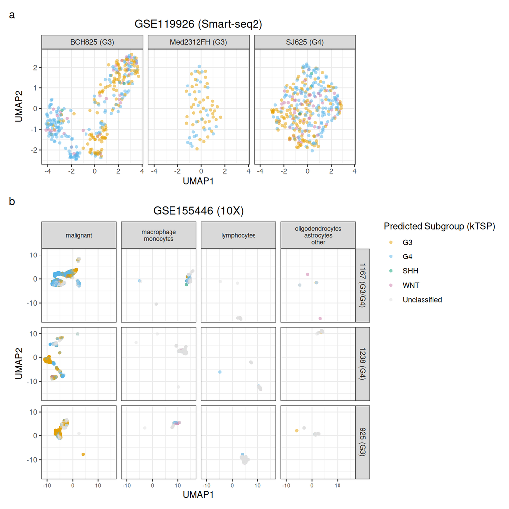

```r
umap_plots <- smartseq_umap_plots / tenx_umap_plots +
  plot_layout(guides = "collect",
              heights = c(1, 2)) +
  plot_annotation(tag_levels = "a")
umap_plots
```

Save to file.

```r
ggsave(file = umap_plots_file,
       plot = umap_plots,
       width = 8.5,
       height = 8.5,
       units = "in")
```